# Fish Video Transect Survey Analysis

Ian Combs – icombs@mote.org

### version: November 08, 2022

This is the analysis pipeline to analyze the community composition from fish video transects. Six experimental 10m x 10m plots were established in August 2020. Three more experimental 10m x 10m plots were established in June of 2021. Three transects of video were captured per site three times 1 month post-outplant and again, three more times 12 months post-outplant. Each transect was swam from the ledge to the hardpan, and 5 minutes elapsed between transects to allow for fish communities to return post diver disturbance. Still frames were pulled from each video every 3 seconds. Using the open source program **Ffmpeg**, the protocol for which can be found in the ../protocols folder within this repository. Fish were identified to the lowest taxonomic level possible, if applicable, the phase of the fish species was noted (terminal, initial, etc).

### All analyses performed with R version 4.2.1

# Basic setup of R environment

## Loading required packages

For the following analyses we will require the use of a number of different R packages. Most of which can be sourced from CRAN, but some may be downloaded from GitHub. We can use the following code to load in the packages and install any packages not previously installed in the R console.

```r
if (!require("pacman")) install.packages("pacman")
pacman::p_load("ggplot2","officer","ggpubr", "rcompanion", "RColorBrewer", "patchwork", "magrittr","reshape2", "stringr", "plyr", "dplyr", "flextable", "tidyr", "tibble", "vegan", "gdata", "forcats")
```

# Loading data

Data generated from reviewing these videos and stills are stored in an excel spreadsheet found in the ../data folder. And loaded in using the `readxlsx()` from the package `readxl`. Note: we are also loading the `officer` package which has a similarly named function, so we are explicitly calling the `read_xlsx()` function from `readxl` using `::` notation.

```r
fish1 <- readxl::read_xlsx("../data/fishSurveyData.xlsx", sheet = 1, col_names = TRUE, na = c("", "N/A", "NA", "NA NA"))
#turning a bunch of the columns into factors, and renaming reviewer1FullSCiName to species
fish1$date <- as.Date.factor(fish1$date)
fish1$site <- as.factor(fish1$site)
fish1$transect <- as.factor(fish1$transect)
fish1$frame <- as.factor(fish1$frame)
fish1$reviewer1SpeciesCm <- as.factor(fish1$reviewer1SpeciesCm)
fish1$reviewer1SpeciesGn <- as.factor(fish1$reviewer1SpeciesGn)
fish1$reviewer1SpeciesSc <- as.factor(fish1$reviewer1SpeciesSc)
fish1$species <- as.factor(fish1$reviewer1FullSciName)
fish1$phase <- as.factor(fish1$phase)

#selecting for species and renaming one of the columns to make it easier to work with
fish1 <- fish1 %>%
  dplyr::filter(date < "2021-12-21")

# selecting only the columns we want to work with and calculating abundance as a proportion. If you want a percentage just multiply by 100 but that makes certain tests and transformations difficult.

fish2 <- fish1 %>% select(date, site, transect, frame, species, count) %>%
group_by(date, site, transect, species) %>%
  add_count() %>%
  rename(tally = 'count') %>%
  summarise(count = sum(tally), n = max(n), avgCount = ((count/n)))
fish3 <- fish2 %>%
  group_by(date, site, species) %>%
  select(date, site, species, avgCount) %>%
  add_count() %>%
  summarise(count = sum(avgCount), n = max(n), avgCount = ((count/n)))
fish <- fish3 %>%
  group_by(date, site, species) %>%
  group_by(date, site) %>%
  mutate(totalObservations = sum(avgCount, na.rm = TRUE)) %>%
  group_by(date, site, species) %>%
  summarise(abundance = avgCount/totalObservations)
```

```r
# Adding a column of Treatment (control vs outplanted)
fish$treatment = if_else(fish$site %in% c("IC-C2", "IC-Z1", "IC-U1"), "Control","Outplanted")

# The nine sites were spread across 3 reefs, so adding a column of reef
fish$reef = if_else(fish$site %in% c("IC-C1", "IC-C2", "IC-C3"), "Site C",
                   if_else(fish$site %in% c("IC-U1", "IC-U2", "IC-U3"), "Site U", "Site Z"))


# Adding a column of timepoint

# ****************** THIS WILL BE CHANGED SEE BELOW ************************
t0 <- "T0"
fish$timePoint <- t0



#need to remove above and change to below when more dates are completed

# fish$timePoint= if_else(fish$date <= ("2021-01-05"), "T0",
#                        if_else(fishY1$date > ("2020-10-15") & fishY1$date <= ("2021-06-15"), "T6",
#                        if_else(fishY1$date > ("2021-06-15") & fishY1$date <= ("2022-01-28"), "T12", "T18")))


#Adding a column of year to delineate which year these plots came from (year1 or year2)
fish$year= if_else(fish$date <= ("2021-01-05"), "Y1", "Y2")#need to remove Y2 and add other contingency's when  time comes
                       # if_else(fish$date > ("2021-01-05") & fishY1$date <= ("2021"), "T6",
                       # if_else(fishY1$date > ("2021-06-15") & fishY1$date <= ("2022-01-28"), "T12", "T18")))



# Taking all of the new columns we just made and turning them all into factors
fish$reef <- as.factor(fish$reef)
fish$year <- as.factor(fish$year)
fish$treatment <- as.factor(fish$treatment)
fish$timePoint <- as.factor(fish$timePoint)
```

# Normality Tests

Here we are exploring the distribution of the data, if the data is not normally distributed we will try to transform the data to meet a normal distribution.

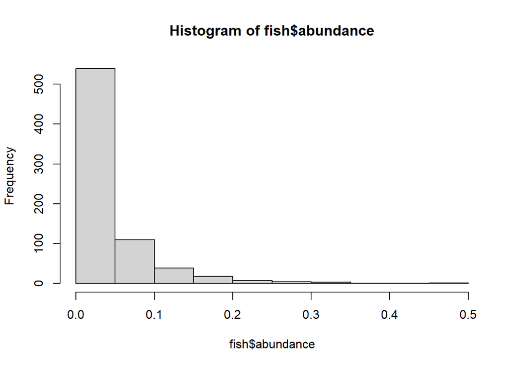

```r
#Testing normality of abundance and count
hist(fish$abundance)
```

```r
shapiro.test(fish$abundance)
```

```
##
##  Shapiro-Wilk normality test
##
## data:  fish$abundance
## W = 0.61056, p-value < 2.2e-16
```

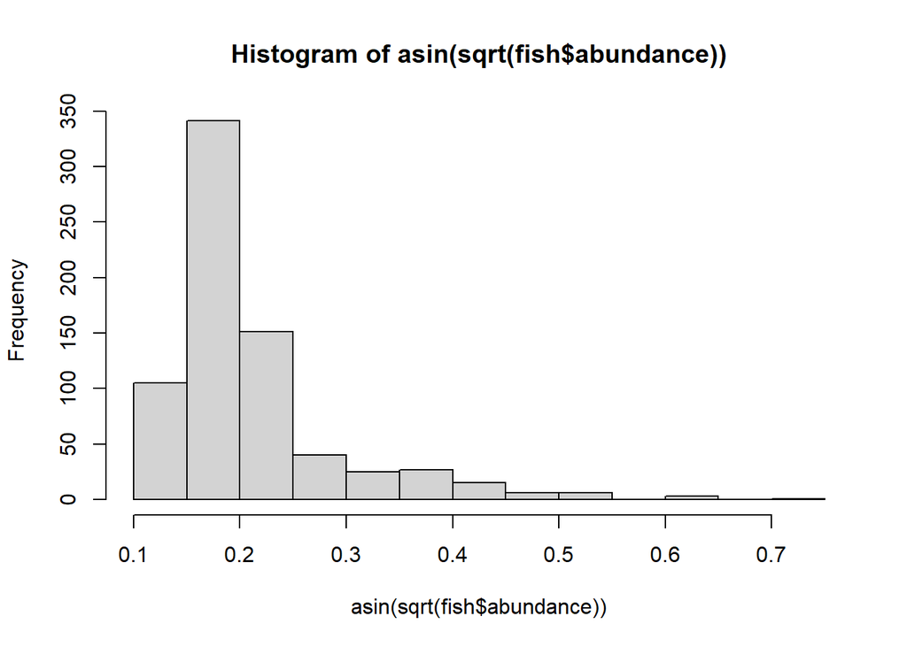

```r
# hist(fish$count)
# shapiro.test(fish$count)

# Trying an arcsine transformation on the proportional abundance data

hist(asin(sqrt(fish$abundance)))
```

```r
shapiro.test(asin(sqrt(fish$abundance)))
```

```
##
##  Shapiro-Wilk normality test
##
## data:  asin(sqrt(fish$abundance))
## W = 0.76442, p-value < 2.2e-16
```

```r
# Trying a square root transformation on the count data

# hist(sqrt(fish$count+1/2))
# shapiro.test(sqrt(fish$count+1/2))

# Trying a square transformation on the count data

# hist((fish$count)^2)
# shapiro.test((fish$count)^2)

# Trying a square transformation on the count data

# hist(exp(fish$count))
# shapiro.test(exp(fish$count))

# Trying a reciprocal transformation on the count data
#
# hist(1/(fish$count))
# shapiro.test(1/(fish$count))
```

# Split Data

Here we are going to split the data between Y1 and Y2 sites.

```r
fishY1 <- fish %>%
  dplyr::select(date, timePoint, year, reef, site, species, abundance) %>%
  dplyr::filter(site %in% c("IC-C1", "IC-C2", "IC-U1", "IC-U2", "IC-Z1", "IC-Z2"))
fishY1 <- na.omit(fishY1)

# fishY1$treatment <- if_else(fishY1$site %in% c("IC-C2", "IC-U1", "IC-Z1"), "Control", "Outplanted")
# year1 <- "Y1"
# fishY1$year <- year1
#
#
# fishY1$timePoint= if_else(fishY1$date <= ("2020-10-15"), "T0",
#                        if_else(fishY1$date > ("2020-10-15") & fishY1$date <= ("2021-06-15"), "T6",
#                        if_else(fishY1$date > ("2021-06-15") & fishY1$date <= ("2022-01-28"), "T12", "T18")))
# fishY1$treatment <- as.factor(fishY1$treatment)
# fishY1$year <- as.factor(fishY1$year)
# fishY1$timePoint <- as.factor(fishY1$timePoint)
# levels(fishY1$timePoint)
# fishY1$timePoint = factor(fishY1$timePoint, levels(fishY1$timePoint)[c(1, 4, 2, 3)])
# levels(fishY1$timePoint)


#Doing the same for Y2 Note: the controls are the same throughout

fishY2 <- fish %>%
  dplyr::select(date, timePoint, year, reef, site, species, abundance) %>%
  dplyr::filter(site %in% c("IC-C2", "IC-U1", "IC-Z1", "IC-C3", "IC-Z3", "IC-U3")) %>%
  dplyr::filter(date > "2020-10-15")
fishY2 <- na.omit(fishY2)

# fishY2$treatment <- if_else(fishY2$site %in% c("IC-C2", "IC-U1", "IC-Z1"), "Control", "Outplanted")
# year2 <- "Y2"
# fishY2$year <- year2
#
# fishY2$timePoint= if_else(fishY2$date <= ("2021-06-15"), "T0",
#                        if_else(fishY2$date > ("2021-06-15") & fishY2$date <= ("2022-01-28"), "T6", "T12"))
#
# fishY2$treatment <- as.factor(fishY2$treatment)
# fishY2$year <- as.factor(fishY2$year)
# fishY2$timePoint <- as.factor(fishY2$timePoint)
# levels(fishY2$timePoint)
# fishY2$timePoint = factor(fishY2$timePoint, levels(fishY2$timePoint)[c(1, 3, 2)])
#



fishTotal <- bind_rows(fishY1, fishY2)
fishTotal <- na.omit(fishTotal)
# fishTotal1 <- fishTotal %>%
#   select(date, timePoint, year, reef, site, species, count) %>%
#   group_by(date, timePoint, year, site) %>%
#   add_count() %>%
#   ungroup() %>%
#   group_by(date, timePoint, year, site, species) %>%
#   summarise(count = sum(count), n = max(sum(count)), abundance = ((count/n)))


# group_by(date, site) %>%
#   add_count() %>%
#   ungroup() %>%
#   group_by(date, site, species) %>%
#   summarise(count = sum(reviewer1Count), n = max(n), abundance = ((count/n)))
```

# PERMANOVA

```r
# set.seed(999)
# adonis2(formula = fishY1$abundance ~ site+reef+year, data = fishY1, method = "euclidian", permutations = 9999)

# pairwise.adonis2(fishY1[6]~species,data=fishY1)
# pairwise.adonis(fishY1[6],factors=fishY1$species,
#                              sim.method='euclidian',p.adjust.m='bonferroni', perm = 999)
#
#
# set.seed(999)
# adonis2(formula = fishY2$abundance ~ treatment*species + timePoint + site, data = fishY2, method = "euclidian", permutations = 9999)
#
# pairwise.adonis(fishY2[6],factors=fishY2$species,
#                              sim.method='euclidian',p.adjust.m='bonferroni', perm = 999)


set.seed(999)
fishPerm <- adonis2(formula = fishTotal$abundance ~ reef + site*year, data = fishTotal, method = "euclidian", permutations = 9999)
```

# PERMANOVA Table

Here we are using the package `officer` to create a publication ready table for our PERMANOVA results.

```r
fishPerm <- tibble::rownames_to_column(fishPerm)


fishPermTab <- fishPerm %>%
  dplyr::rename("Factor" = "rowname") %>%
  dplyr::rename("Degrees of Freedom" = "Df") %>%
  dplyr::rename("Sum of Squares" = "SumOfSqs") %>%
  dplyr::rename("Pseudo.F" = "F") %>%
  dplyr::rename( "p.value"  = "Pr(>F)") %>%

mutate_if(is.numeric, round, digits = 3) %>%
mutate(p.value = replace(p.value, p.value >= 0.05, "ns")) %>%
mutate(p.value = replace(p.value, p.value < 0.001, "< 0.001")) %>%
mutate_if(is.character, str_replace_all, pattern = "-", replacement = "–") %>%
flextable() %>%
set_header_labels(Data.set = "Data set") %>%
flextable::compose(part = "header", j = "Degrees of Freedom", value = as_paragraph("Degrees of Freedom")) %>%
flextable::compose(part = "header", j = "Pseudo.F", value = as_paragraph("Pseudo-F")) %>%
flextable::compose(part = "header", j = "p.value", value = as_paragraph(as_i("p"), "-value")) %>%
autofit() %>%
font(fontname = "Times New Roman", part = "all") %>%
fontsize(size = 12, part = "all") %>%
bold(part = "header") %>%
colformat_num(j = 'Degrees of Freedom', digits = 2) %>%
colformat_num(j = "Pseudo.F", digits = 2) %>%
colformat_num(j = "p.value", digits = 4, na_str = "ns") %>%
align_nottext_col(align = "center", header = TRUE, footer = TRUE) %>%
align(align = "center", j = "p.value")

fishDoc = read_docx()
fishDoc = body_add_flextable(fishDoc, value = fishPermTab)
print(fishDoc, target = "../tables/fishSurveyPERMANOVATable.docx")
fishPermTab
```

| Factor | Degrees of Freedom | Sum of Squares | R2 | Pseudo-F | p-value |
| --- | --- | --- | --- | --- | --- |
| reef | 2 | 0.019 | 0.009 | 4.831 | 0.008 |
| site | 6 | 0.015 | 0.007 | 1.238 | ns |
| year | 1 | 0.000 | 0.000 | 0.039 | ns |
| site:year | 4 | 0.006 | 0.003 | 0.776 | ns |
| Residual | 1,049 | 2.072 | 0.981 |  |  |
| Total | 1,062 | 2.112 | 1.000 |  |  |

# Plotting the data

To visualize the data and what our species composition looks like at our sites, we are going to plot the data in a few different ways.

[figure not shown]

```r
myColors <- c("#006BFF", "#277B00", "#ff0000", "#97DE00", "#00ffff", "#6495ed" , '#843BFF', "#ffd700", "#BF5B9A", "#003E94", "#FF9200", "#60f542", '#F96D67', '#9067F9', '#F967C1')


fishStack <- fish %>%
  filter(abundance > .02) %>%
  droplevels()
# vpi1$class = factor(vpi1$class, levels(vpi1$class)[c(2,6,3,4,5,1)])



y1FishStack1 <- ggplot(fishStack, aes(x = site, y = abundance, fill = fct_reorder(species, abundance))) +
    geom_bar(stat = "identity", colour = "black", position = position_stack(reverse = FALSE))+
    labs(y = "Relative Abundance > 2%", x = "Site", fill = "Species", title = "Relative Species Abundance")+
# scale_fill_manual(values=myColors)+
    facet_wrap(~year)

y1FishStack <- y1FishStack1+theme(
    axis.text.x = element_text(size = 20, colour = "black", angle = 45, vjust = 0.5, hjust = 0.5, face= "bold"),
    axis.title.x = element_text(size = 40, color = "black", face = "bold"),
    axis.title.y = element_text(size = 40, face = "bold"),
    axis.text.y = element_text(colour = "black", size = 20, face = "bold"),
    legend.title = element_text(size = 40, face = "bold"),
    legend.text = element_text(size = 12, face = "bold", colour = "black"),
    panel.grid.major = element_line(size = 0.5, linetype = 'solid', colour = "white"),
    panel.background = element_rect(fill = '#F5F5F5'),
    plot.title = element_text(size = 40, face = "bold"),
    axis.line = element_line(colour = "black"),
    axis.ticks = element_line(color="black"),
    text = element_text(size=40, color="black"),
    legend.position = "right")

y1FishStack
```

```r
ggsave("../figures/baselineFishSurveyPlot.png", plot = y1FishStack, width = 20, height = 15, units = "in", dpi = 600)










#
# # myColors <- paletteer_c("harrypotter::gryffindor", 6, direction = 1 )
# #myColors <- paletteer_c("pals::ocean.balance", 6, direction = 1)
# #Color Palette using a selection of Mote's preferred colors
# myColors <- c("#d2232a", "#ca581f", "#f26522", "#85b034", "#00ae9d", "#78779e")
#
# # Using this just to plot the top 2% of species
# vpi1 <- vpi %>%
#   filter(abundance > 2) %>%
#   droplevels()
# vpi1$class = factor(vpi1$class, levels(vpi1$class)[c(2,6,3,4,5,1)])
#
#
#
#
# fishStack1 <- ggplot(fish, aes(x = site, y = abundance, fill = species, group = reef))+
#                       geom_bar(stat = 'identity', color = 'black', position = position_stack(reverse = TRUE))+
#                       ylim(0,100)+
#                       labs(y = "Relative Abundance (%)", fill = "Class", title = "Relative Species Abundance > 2%")+
#                       #scale_fill_manual(values = myColors)+
#                       facet_grid(treatment ~ time)
#
# vpiStack <- vpiStack1+theme(
#     axis.text.x = element_text(size = 40, colour = "black", vjust = 0.5, hjust = 0.5, face= "bold"),
#     axis.title.x = element_blank(),
#     axis.title.y = element_text(size = 40, face = "bold"),
#     axis.text.y = element_text(colour = "black", size = 40, face = "bold"),
#     legend.title = element_text(size = 40, face = "bold"),
#     legend.text = element_text(size = 36, face = "bold", colour = "black"),
#     panel.grid.major = element_line(size = 0.5, linetype = 'solid', colour = "white"),
#     panel.background = element_rect(fill = '#F5F5F5'),
#     plot.title = element_text(size = 40, face = "bold"),
#     axis.line = element_line(colour = "black"),
#     axis.ticks = element_line(color="black"),
#     text = element_text(size=40, color="black"),
#     legend.position = "bottom")
# vpiStack
#
#
#
#
#
#
#
#
#
# #subsetting for just one time point, and filtering outo anything lower than 2% abundance
#
#
# fishPlot <- subset(fish, date == "2020-12-14")
# fishPlot <- subset(fish, site == "IC-C1")
#
# fishPlot <- fishPlot %>%
#   group_by(site, date, transect, reviewer1FullSciName) %>%
#   summarise(mean(reviewer1Count)) %>%
#   ungroup() %>%
#   group_by(site, date, reviewer1FullSciName) %>%
#   summarise(mean(reviewer1Count))
#
#
# fishPlot <- fish %>%
#   filter(date <"2021-07-20") %>%
#   filter(abundance > 2) %>%
#   droplevels()
# levels(fishPlot$reviewer1FullSciName)
#
#
# vpi1 <- vpi %>%
#   filter(abundance > 2) %>%
#   droplevels()
# vpi1$class = factor(vpi1$class, levels(vpi1$class)[c(2,6,3,4,5,1)])
#
#
#
# fishStack1 <- ggplot(fish, aes(x = site, y = abundnace, fill = reviewer1FullSciName)) +
#     geom_bar(stat = "identity", colour = "black", position = position_stack(reverse = FALSE))+
#     labs(y = "Relative Abundance (%)", fill = "Species", title = "Relative Species Abundance")+
#     facet_wrap(date~. , scale = 'free')
#     #scale_fill_manual(values = myColors)+
#     #scale_x_discrete(name = "Site", limits = c("c1", "c2", "u1", "u2", "z1", "z2"), labels = c("C1", "C2", "U1", "U2", "Z1", "Z2"))
#
# vpiStack <- vpiStack1+theme(
#     axis.text.x = element_text(size = 40, colour = "black", vjust = 0.5, hjust = 0.5, face= "bold"),
#     axis.title.x = element_blank(),
#     axis.title.y = element_text(size = 40, face = "bold"),
#     axis.text.y = element_text(colour = "black", size = 40, face = "bold"),
#     legend.title = element_text(size = 40, face = "bold"),
#     legend.text = element_text(size = 36, face = "bold", colour = "black"),
#     panel.grid.major = element_line(size = 0.5, linetype = 'solid', colour = "white"),
#     panel.background = element_rect(fill = '#F5F5F5'),
#     plot.title = element_text(size = 40, face = "bold"),
#     axis.line = element_line(colour = "black"),
#     axis.ticks = element_line(color="black"),
#     text = element_text(size=40, color="black"),
#     legend.position = "bottom")
# vpiStack
```

[figure not shown]